# Simulation Studies: Continuous Outcome (ACTG175)

Subgroup Identification with Mean Difference in CD4 Change

Author

Larry F. León

Published

April 24, 2026

# 1 Introduction

## 1.1 Motivation

This document validates the ForestSearch GLM extension for **continuous outcomes** using the ACTG175 trial. Instead of binarising CD4 response (`cd420 > cd40`), we use the raw CD4 change (`cd420 - cd40`) as a continuous endpoint analysed via Gaussian GLM with mean difference (MD) as the effect measure.

This tests the full pipeline:

1. `generate_glm_dgm()` with `outcome_type = "continuous"`: potential means $\mu_0$, $\mu_1$
2. `calibrate_glm_interaction()` to find `k_inter` producing a target MD in the subgroup
3. `simulate_from_glm_dgm()` generating $Y = \mu + \varepsilon$, $\varepsilon \sim N(0, \sigma^2)$
4. `run_simulation_analysis()` dispatching via `"glm_dgm"` class
5. Operating characteristics via `format_oc_results()` and `build_estimation_table()`

## 1.2 Clinical Context

In the ACTG175 trial, CD4 count at 20 weeks is a well-established surrogate for clinical outcomes in HIV. The combination therapy (ZDV+ddI) generally produces larger CD4 increases than monotherapy (ddI). The question is whether there exists a subgroup where the benefit of combination therapy is particularly pronounced.

Using the switched-treatment convention (ddI = treat = 1), a positive `k_inter` increases E[Y|Q, treat=1], creating a subgroup Q where ddI has an extreme positive effect on CD4 change. ForestSearch detects this subgroup because MD(Q) exceeds the threshold, while the population baseline effect is negative (ddI generally hurts). This mirrors the working binary simulation.

# 2 Data Preparation

```r
library(forestsearch)
library(speff2trial)
library(data.table)
library(gt)
library(ggplot2)
library(doFuture)
library(foreach)

# -- Safe foreach result collection -------------------------------------------
# collect_results() now lives in forestsearch (R/forestsearch_helpers.R).
# Called via ::: since it is an internal (unexported) utility.

timings <- list()
```

```r
t0 <- proc.time()[3]

actg_df <- subset(speff2trial::ACTG175, arms %in% actg_arms)
actg_df$id <- seq_len(nrow(actg_df))

# Original treatment: arm 1 = 1, arm 3 = 0
actg_df$treat_orig <- ifelse(actg_df$arms == actg_treat_arm, 1L, 0L)

# Switched treatment for benefit search
actg_df$treat <- 1L - actg_df$treat_orig

# Continuous outcome: CD4 change from baseline to 20 weeks
actg_df$cd4_change <- actg_df$cd420 - actg_df$cd40

# Remove missing cd420
n_before <- nrow(actg_df)
actg_df <- actg_df[!is.na(actg_df$cd420), ]
n_after  <- nrow(actg_df)

cat(sprintf("ACTG175 arms 1 vs 3: N = %d -> %d after removing %d missing\n",
    n_before, n_after, n_before - n_after))
```

```
#> ACTG175 arms 1 vs 3: N = 1083 -> 1083 after removing 0 missing
```

```r
cat(sprintf("CD4 change: mean = %.1f, SD = %.1f, range = [%d, %d]\n",
    mean(actg_df$cd4_change), sd(actg_df$cd4_change),
    min(actg_df$cd4_change), max(actg_df$cd4_change)))
```

```
#> CD4 change: mean = 40.2, SD = 130.4, range = [-634, 666]
```

```r
cat(sprintf("  ZDV+ddI (arm 1): mean = %.1f\n",
    mean(actg_df$cd4_change[actg_df$treat_orig == 1])))
```

```
#>   ZDV+ddI (arm 1): mean = 54.4
```

```r
cat(sprintf("  ddI (arm 3):     mean = %.1f\n",
    mean(actg_df$cd4_change[actg_df$treat_orig == 0])))
```

```
#>   ddI (arm 3):     mean = 26.9
```

```r
cat(sprintf("  MD (combo - mono, original scale): %.1f\n",
    mean(actg_df$cd4_change[actg_df$treat_orig == 1]) -
    mean(actg_df$cd4_change[actg_df$treat_orig == 0])))
```

```
#>   MD (combo - mono, original scale): 27.6
```

```r
# Discretise covariates (same as binary simulation)
actg_df$z1  <- as.factor(ifelse(actg_df$age > actg_age_cut, 1L, 0L))
actg_df$z2  <- as.factor(ifelse(actg_df$preanti <= actg_preanti_cut, 1L, 0L))
actg_df$z3  <- as.factor(ifelse(actg_df$wtkg <= 75, 1L, 0L))
actg_df$z4  <- as.factor(ifelse(
  actg_df$karnof <= median(actg_df$karnof), 1L, 0L))
actg_df$z5  <- as.factor(ifelse(
  actg_df$cd40 <= median(actg_df$cd40), 1L, 0L))
actg_df$z6  <- as.factor(ifelse(
  actg_df$cd80 <= median(actg_df$cd80), 1L, 0L))
actg_df$z7  <- as.factor(actg_df$hemo)
actg_df$z8  <- as.factor(actg_df$homo)
actg_df$z9  <- as.factor(actg_df$drugs)
actg_df$z10 <- as.factor(actg_df$race)
actg_df$z11 <- as.factor(actg_df$gender)
actg_df$z12 <- as.factor(actg_df$symptom)

# Reference subgroup Q
actg_df$flag_Q_ref <- as.integer(actg_df$z1 == 1 & actg_df$z2 == 1)
cat(sprintf("\nSubgroup Q: age > %d AND preanti <= %.0f\n",
    actg_age_cut, actg_preanti_cut))
```

```
#>
#> Subgroup Q: age > 34 AND preanti <= 744
```

```r
cat(sprintf("  Q prevalence: %d / %d (%.1f%%)\n",
    sum(actg_df$flag_Q_ref), nrow(actg_df),
    100 * mean(actg_df$flag_Q_ref)))
```

```
#>   Q prevalence: 382 / 1083 (35.3%)
```

```r
# CD4 change by subgroup (original scale)
cat("\nCD4 change by subgroup (original treatment scale):\n")
```

```
#>
#> CD4 change by subgroup (original treatment scale):
```

```r
for (grp in c("Q", "Qc")) {
  idx <- if (grp == "Q") actg_df$flag_Q_ref == 1 else actg_df$flag_Q_ref == 0
  md <- mean(actg_df$cd4_change[idx & actg_df$treat_orig == 1]) -
    mean(actg_df$cd4_change[idx & actg_df$treat_orig == 0])
  cat(sprintf("  %s (n=%d): MD(combo - mono) = %.1f\n",
      grp, sum(idx), md))
}
```

```
#>   Q (n=382): MD(combo - mono) = 43.3
#>   Qc (n=701): MD(combo - mono) = 18.7
```

```r
timings$data_prep <- proc.time()[3] - t0
```

# 3 Creating the Continuous DGM

## 3.1 Step 1: Initial DGM

```r
t0 <- proc.time()[3]

dgm_alt_init <- generate_glm_dgm(
  data          = actg_df,
  factor_vars   = dgm_factor_vars,
  outcome_var   = "cd4_change",
  treatment_var = "treat",
  outcome_type  = "continuous",
  effect_measure = "MD",
  subgroup_vars = dgm_subgroup_vars,
  subgroup_cuts = dgm_subgroup_cuts,
  model         = "alt",
  k_inter       = 0,
  n_super       = dgm_n_super,
  seed          = sim_seed,
  verbose       = TRUE
)
```

```
#> === generate_glm_dgm() ===
#>   outcome_type:   continuous
#>   effect_measure: MD
#>   model:          alt
#>   k_inter:        0.000
#>   k_treat:        1.000
#>   n_super:        5000
#>   n observations: 1083
#>   Dropped single-level factors: z4
#>
#> === Subgroup Definitions ===
#>    z1 == 1
#>     Proportion in subgroup: 0.488
#>    z2 == 1
#>     Proportion in subgroup: 0.75
#>
#> Overall subgroup (all conditions met):
#>   Size: 382 out of 1083
#>   Proportion: 0.353
#>
#> Baseline GLM fit (no interaction):
#>   AIC: 13589.4
#>   Treatment coefficient: -26.2552 (MD = -26.255)
#>   Interaction shift (k_inter): 0.0000
#>
#> === DGM Summary ===
#>   Effect(Q):   -26.2552  (MD)
#>   Effect(Qc):  -26.2552  (MD)
#>   Effect(ITT): -26.2552  (MD)
#>   Subgroup prevalence: 34.5%
```

```r
cat("\n=== Initial ACTG175 Continuous DGM ===\n")
```

```
#>
#> === Initial ACTG175 Continuous DGM ===
```

```r
cat("  MD(Q):  ", round(dgm_alt_init$hazard_ratios$harm_subgroup, 1), "\n")
```

```
#>   MD(Q):   -26.3
```

```r
cat("  MD(Qc): ", round(dgm_alt_init$hazard_ratios$no_harm_subgroup, 1), "\n")
```

```
#>   MD(Qc):  -26.3
```

```r
cat("  MD(ITT):", round(dgm_alt_init$hazard_ratios$overall, 1), "\n")
```

```
#>   MD(ITT): -26.3
```

```r
cat("  sigma:  ", round(dgm_alt_init$model_params$sigma, 1), "\n")
```

```
#>   sigma:   127.5
```

```r
timings$dgm_init <- proc.time()[3] - t0
```

## 3.2 Step 2: Calibrate for Target MD

```r
t0 <- proc.time()[3]

dgm_calibrated <- calibrate_glm_interaction(
  data          = actg_df,
  factor_vars   = dgm_factor_vars,
  outcome_var   = "cd4_change",
  treatment_var = "treat",
  target_effect = cal_target_md,
  outcome_type  = "continuous",
  effect_measure = "MD",
  subgroup_vars = dgm_subgroup_vars,
  subgroup_cuts = dgm_subgroup_cuts,
  k_inter_range = cal_k_grid_range,
  grid_step     = cal_grid_step,
  n_super       = dgm_n_super,
  seed          = sim_seed,
  verbose       = TRUE
)
```

```
#> Calibrating: target MD = 40.000
#>   Grid: 0.00 to 120.00 by 2.000 (61 values)
#>   Best: k_inter = 66.000 -> Effect(Q) = 39.7448 (target: 40.000)
#> === generate_glm_dgm() ===
#>   outcome_type:   continuous
#>   effect_measure: MD
#>   model:          alt
#>   k_inter:        66.000
#>   k_treat:        1.000
#>   n_super:        5000
#>   n observations: 1083
#>   Dropped single-level factors: z4
#>
#> === Subgroup Definitions ===
#>    z1 == 1
#>     Proportion in subgroup: 0.488
#>    z2 == 1
#>     Proportion in subgroup: 0.75
#>
#> Overall subgroup (all conditions met):
#>   Size: 382 out of 1083
#>   Proportion: 0.353
#>
#> Baseline GLM fit (no interaction):
#>   AIC: 13589.4
#>   Treatment coefficient: -26.2552 (MD = -26.255)
#>   Interaction shift (k_inter): 66.0000
#>
#> === DGM Summary ===
#>   Effect(Q):   39.7448  (MD)
#>   Effect(Qc):  -26.2552  (MD)
#>   Effect(ITT): -3.5116  (MD)
#>   Subgroup prevalence: 34.5%
#>
#> Calibration complete: k_inter = 66.000
#>   Effect(Q):   39.7448
#>   Effect(Qc):  -26.2552
#>   Effect(ITT): -3.5116
```

```r
cat("\n=== Calibrated ACTG175 Continuous DGM ===\n")
```

```
#>
#> === Calibrated ACTG175 Continuous DGM ===
```

```r
cat("  Switched scale (ddI = treat):\n")
```

```
#>   Switched scale (ddI = treat):
```

```r
cat("    MD(Q):  ", round(dgm_calibrated$hazard_ratios$harm_subgroup, 1),
    " (target:", cal_target_md, ")\n")
```

```
#>     MD(Q):   39.7  (target: 40 )
```

```r
cat("    MD(Qc): ", round(dgm_calibrated$hazard_ratios$no_harm_subgroup, 1), "\n")
```

```
#>     MD(Qc):  -26.3
```

```r
cat("    MD(ITT):", round(dgm_calibrated$hazard_ratios$overall, 1), "\n")
```

```
#>     MD(ITT): -3.5
```

```r
cat("  -> Original scale: MD(Q) =",
    round(-dgm_calibrated$hazard_ratios$harm_subgroup, 1), "\n")
```

```
#>   -> Original scale: MD(Q) = -39.7
```

```r
cat("  k_inter:", round(dgm_calibrated$model_params$k_inter, 2), "\n")
```

```
#>   k_inter: 66
```

```r
cat("  sigma:  ", round(dgm_calibrated$model_params$sigma, 1), "\n")
```

```
#>   sigma:   127.5
```

```r
timings$calibrate <- proc.time()[3] - t0
```

### 3.2.1 Calibration Curve

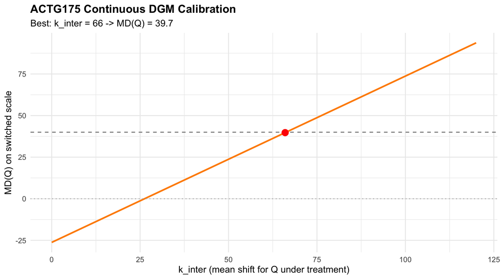

Calibration of k_inter: MD(Q) as a function of the interaction parameter.

```r
cal_grid <- seq(cal_k_grid_range[1], cal_k_grid_range[2], by = cal_grid_step)
cal_md_Q <- vapply(cal_grid, function(k) {
  d <- generate_glm_dgm(
    data = actg_df, factor_vars = dgm_factor_vars,
    outcome_var   = "cd4_change", treatment_var = "treat",
    outcome_type = "continuous", effect_measure = "MD",
    subgroup_vars = dgm_subgroup_vars,
    subgroup_cuts = dgm_subgroup_cuts, model = "alt",
    k_inter = k, n_super = dgm_n_super, seed = sim_seed
  )
  d$hazard_ratios$harm_subgroup
}, numeric(1))

cal_df <- data.frame(k_inter = cal_grid, md_Q = cal_md_Q)
best_k <- dgm_calibrated$model_params$k_inter

ggplot(cal_df, aes(x = k_inter, y = md_Q)) +
  geom_line(linewidth = 1, colour = "darkorange") +
  geom_hline(yintercept = cal_target_md, linetype = "dashed",
             colour = "grey50") +
  geom_hline(yintercept = 0, linetype = "dotted",
             colour = "grey70") +
  geom_point(
    data = data.frame(k_inter = best_k,
                      md_Q = dgm_calibrated$hazard_ratios$harm_subgroup),
    colour = "red", size = 4, shape = 16
  ) +
  labs(
    x = "k_inter (mean shift for Q under treatment)",
    y = "MD(Q) on switched scale",
    title = "ACTG175 Continuous DGM Calibration",
    subtitle = sprintf("Best: k_inter = %.0f -> MD(Q) = %.1f",
      best_k, dgm_calibrated$hazard_ratios$harm_subgroup)
  ) +
  theme_minimal(base_size = 12) +
  theme(plot.title = element_text(face = "bold"))
```

## 3.3 Step 3: Null DGM

```r
t0 <- proc.time()[3]

dgm_null <- generate_glm_dgm(
  data          = actg_df,
  factor_vars   = dgm_factor_vars,
  outcome_var   = "cd4_change",
  treatment_var = "treat",
  outcome_type  = "continuous",
  effect_measure = "MD",
  subgroup_vars = dgm_subgroup_vars,
  subgroup_cuts = dgm_subgroup_cuts,
  model         = "null",
  n_super       = dgm_n_super,
  seed          = sim_seed,
  verbose       = TRUE
)
```

```
#> === generate_glm_dgm() ===
#>   outcome_type:   continuous
#>   effect_measure: MD
#>   model:          null
#>   k_inter:        0.000
#>   k_treat:        1.000
#>   n_super:        5000
#>   n observations: 1083
#>   Dropped single-level factors: z4
#>
#> === Subgroup Definitions ===
#>    z1 == 1
#>     Proportion in subgroup: 0.488
#>    z2 == 1
#>     Proportion in subgroup: 0.75
#>
#> Overall subgroup (all conditions met):
#>   Size: 382 out of 1083
#>   Proportion: 0.353
#>
#> Baseline GLM fit (no interaction):
#>   AIC: 13589.4
#>   Treatment coefficient: -26.2552 (MD = -26.255)
#>   Interaction shift (k_inter): 0.0000 (null model: forced to 0)
#>
#> === DGM Summary ===
#>   Effect(Q):   NA  (MD)
#>   Effect(Qc):  -26.2552  (MD)
#>   Effect(ITT): -26.2552  (MD)
#>   Subgroup prevalence: 0.0%
```

```r
cat("\n=== ACTG175 Null DGM ===\n")
```

```
#>
#> === ACTG175 Null DGM ===
```

```r
cat("  MD(ITT):", round(dgm_null$hazard_ratios$overall, 1), "\n")
```

```
#>   MD(ITT): -26.3
```

```r
cat("  MD(Q):  ", round(dgm_null$hazard_ratios$harm_subgroup, 1), "\n")
```

```
#>   MD(Q):   NA
```

```r
cat("  MD(Qc): ", round(dgm_null$hazard_ratios$no_harm_subgroup, 1), "\n")
```

```
#>   MD(Qc):  -26.3
```

```r
timings$dgm_null <- proc.time()[3] - t0
```

# 4 Single Trial Verification

```r
t0 <- proc.time()[3]

df_single <- simulate_from_glm_dgm(
  dgm  = dgm_calibrated,
  n    = sim_n_sample,
  seed = sim_seed + 1L
)

cat(sprintf("Single trial: N = %d\n", nrow(df_single)))
```

```
#> Single trial: N = 1000
```

```r
cat(sprintf("  CD4 change: mean = %.1f, SD = %.1f\n",
    mean(df_single$y_sim), sd(df_single$y_sim)))
```

```
#>   CD4 change: mean = 51.1, SD = 130.7
```

```r
cat(sprintf("  Q prevalence: %.1f%%\n",
    100 * mean(df_single$flag_harm)))
```

```
#>   Q prevalence: 35.5%
```

```r
# Verify MD in the simulated data
md_sim <- mean(df_single$y_sim[df_single$treat_sim == 1]) -
  mean(df_single$y_sim[df_single$treat_sim == 0])
cat(sprintf("  Simulated ITT MD: %.1f (DGM: %.1f)\n",
    md_sim, dgm_calibrated$hazard_ratios$overall))
```

```
#>   Simulated ITT MD: -5.9 (DGM: -3.5)
```

```r
timings$single_trial <- proc.time()[3] - t0
```

# 5 Running Simulation Studies

## 5.1 Setup

```r
plan(multisession, workers = n_workers)
cat("Using", n_workers, "parallel workers\n")
```

```
#> Using 12 parallel workers
```

```r
confounders_actg <- dgm_calibrated$factor_vars

fs_params <- list(
  outcome.name           = "y_sim",
  treat.name             = "treat_sim",
  id.name                = "id",

  # GLM pipeline
  outcome_type           = "continuous",
  effect_measure         = "MD",

  # Variable screening
  use_lasso              = fs_use_lasso,
  use_grf                = fs_use_grf,

  # Consistency algorithm (v0.2.0 default: 3-10x speedup)
  use_twostage           = TRUE,

  # Subgroup detection thresholds (identity scale)
  effect.threshold       = fs_md_threshold,
  consistency.threshold  = fs_md_consistency,
  pconsistency.threshold = fs_pconsistency,

  # Constraints
  fs.splits              = fs_splits,
  n.min                  = fs_n_min,
  d0.min                 = fs_d0_min,
  d1.min                 = fs_d1_min,
  maxk                   = fs_maxk,
  vi.grf.min             = fs_vi_grf_min,
  seedit                 = fs_seedit,

  parallel_args          = list(
    plan = "sequential", workers = 1, show_message = FALSE
  )
)

# -- GRF standalone parameter overrides ----------------------------------------
# Supplied to run_simulation_analysis(grf_params = ...); the GLM path
# automatically injects outcome_type = "continuous" and effect_measure = "MD".
# adverse_outcome is explicitly overridden to TRUE here (see the detailed
# comment in the setup chunk) -- without the override, run_simulation_analysis()
# defaults it to FALSE for continuous outcomes, which is correct for harm
# searches but WRONG for benefit-search-via-switched-treatment as used here.
grf_params <- list(
  dmin.grf        = grf_dmin,
  maxdepth        = grf_maxdepth,
  sg.criterion    = grf_sg_criterion,
  tune_grf        = grf_tune,
  adverse_outcome = grf_adverse_outcome
)
```

## 5.2 Alternative Hypothesis Simulations

```r
cat("Running", nsims_alt, "simulations under H1...\n")
```

```
#> Running 25 simulations under H1...
```

```r
t0 <- proc.time()[3]

results_alt_raw <- foreach(
  sim = seq_len(nsims_alt),
  .errorhandling = "pass",
  .options.future = list(
    packages = c("forestsearch", "survival", "data.table", "future"),
    seed = TRUE
  )
) %dofuture% {
  future::plan("sequential")
  run_simulation_analysis(
    sim_id           = sim,
    dgm              = dgm_calibrated,
    n_sample         = sim_n_sample,
    confounders_base = confounders_actg,
    n_add_noise      = sim_n_noise,
    run_fs           = run_fs,
    run_fs_grf       = run_fs_grf,
    run_grf          = run_grf,
    fs_params        = fs_params,
    grf_params       = grf_params,
    verbose          = FALSE
  )
}

timings$sims_alt <- proc.time()[3] - t0

results_alt <- forestsearch::collect_results(results_alt_raw, "H1 alt")
n_failed_alt <- attr(results_alt, "n_failed")

cat("Completed in", round(timings$sims_alt / 60, 1), "minutes\n")
```

```
#> Completed in 0.2 minutes
```

```r
cat("Results:", nrow(results_alt), "rows\n")
```

```
#> Results: 50 rows
```

```r
if (n_failed_alt > 0) cat(sprintf("  *** %d FAILED ***\n", n_failed_alt))
cat(sprintf("Detection rate: %.1f%%\n",
    100 * mean(results_alt$any.H[results_alt$analysis == "FS"])))
```

```
#> Detection rate: 76.0%
```

## 5.3 Null Hypothesis Simulations

```r
# Reset worker pool to prevent memory accumulation from alt sims.
# Without this, null sims run on bloated workers and can be ~20x slower.
# reset_workers() consolidates: plan(sequential) -> gc() -> Sys.sleep() ->
# plan(multisession, workers = n_workers).  Exported from forestsearch
# v0.2.0 (R/forestsearch_helpers.R).
forestsearch::reset_workers(workers = n_workers)
```

```
#> reset_workers: plan reset to FutureStrategy with 12 worker(s) (was FutureStrategy).
```

```r
cat("Running", nsims_null, "simulations under H0...\n")
```

```
#> Running 50 simulations under H0...
```

```r
t0 <- proc.time()[3]

results_null_raw <- foreach(
  sim = seq_len(nsims_null),
  .errorhandling = "pass",
  .options.future = list(
    packages = c("forestsearch", "survival", "data.table", "future"),
    seed = TRUE
  )
) %dofuture% {
  future::plan("sequential")
  run_simulation_analysis(
    sim_id           = sim,
    dgm              = dgm_null,
    n_sample         = sim_n_sample,
    confounders_base = confounders_actg,
    n_add_noise      = sim_n_noise,
    run_fs           = run_fs,
    run_fs_grf       = run_fs_grf,
    run_grf          = run_grf,
    fs_params        = fs_params,
    grf_params       = grf_params,
    verbose          = FALSE
  )
}

timings$sims_null <- proc.time()[3] - t0

results_null <- forestsearch::collect_results(results_null_raw, "H0 null")
n_failed_null <- attr(results_null, "n_failed")

cat("Completed in", round(timings$sims_null / 60, 1), "minutes\n")
```

```
#> Completed in 0.3 minutes
```

```r
if (n_failed_null > 0) cat(sprintf("  *** %d FAILED ***\n", n_failed_null))
cat(sprintf("False discovery rate: %.1f%%\n",
    100 * mean(results_null$any.H[results_null$analysis == "FS"])))
```

```
#> False discovery rate: 4.0%
```

```r
plan(sequential)
```

```r
if (save_results) {
  if (!dir.exists(output_dir)) dir.create(output_dir, recursive = TRUE)

  bundle <- list(
    results_alt    = results_alt,
    results_null   = results_null,
    dgm_calibrated = dgm_calibrated,
    dgm_null       = dgm_null,
    config = list(
      nsims_alt    = nsims_alt,
      nsims_null   = nsims_null,
      n_sample     = sim_n_sample,
      n_noise      = sim_n_noise,
      n_workers    = n_workers,
      fs_params    = fs_params,
      grf_params   = grf_params,
      target_md    = cal_target_md,
      subgroup     = paste(dgm_subgroup_vars, collapse = " & ")
    ),
    true_effects = list(
      md_Q     = dgm_calibrated$hazard_ratios$harm_subgroup,
      md_Qc    = dgm_calibrated$hazard_ratios$no_harm_subgroup,
      md_ITT   = dgm_calibrated$hazard_ratios$overall,
      k_inter  = dgm_calibrated$model_params$k_inter,
      sigma    = dgm_calibrated$model_params$sigma
    ),
    timings = timings
  )

  fname <- sprintf("actg175_continuous_simulations_%dalts_%dnulls.rds",
      nsims_alt, nsims_null)
  saveRDS(bundle, file.path(output_dir, fname))
  cat("Saved:", file.path(output_dir, fname), "\n")
} else {
  cat("save_results = FALSE; skipping save.\n")
}
```

```
#> Saved: _data/actg175_continuous_simulations_25alts_50nulls.rds
```

# 6 Results

## 6.1 Operating Characteristics Under H1

```r
t0 <- proc.time()[3]

format_oc_results(
  results_alt,
  metrics   = c("detection", "classification"),
  digits    = 2,
  digits_hr = 1,
  title     = "ACTG175 Continuous: Subgroup Identification",
  subtitle  = sprintf(
    "n = %d, %d sims, MD(Q) = %.1f, MD(Qc) = %.1f (switched)",
    sim_n_sample, nsims_alt,
    dgm_calibrated$hazard_ratios$harm_subgroup,
    dgm_calibrated$hazard_ratios$no_harm_subgroup
  ),
  subgroup_notation = sg_notation
)
```

ACTG175 Continuous: Subgroup Identification

n = 1000, 25 sims, MD(Q) = 39.7, MD(Qc) = -26.3 (switched)

| Method | Sims | Found | Classification Sen | Classification Spec | Classification PPV | Classification NPV |
| --- | --- | --- | --- | --- | --- | --- |
| FS | 25 | 0.76 | 0.40 | 0.88 | 0.61 | 0.86 |
| GRF | 25 | 0.36 | 0.35 | 0.73 | 0.30 | 1.00 |

```r
build_estimation_table(
  results         = results_alt,
  dgm             = dgm_calibrated,
  analysis_method = "FS",
  subtitle = sprintf(
    "ACTG175 Continuous DGM | n = %d, %d sims",
    sim_n_sample, nsims_alt
  ),
  font_size = 16,
  subgroup_notation = sg_notation
)
```

Estimation Properties

ACTG175 Continuous DGM | n = 1000, 25 sims (FS: 19/25 (76%) estimable)

|  | Avg | SD | Min | Max | b† (%) |
| --- | --- | --- | --- | --- | --- |
| Q̂: 19 estimable, avg \|Q̂\| = 219, θ†(Q) = -39.74 |  |  |  |  |  |
| θ̂(Q̂) | -58.89 | 17.14 | -95.85 | -32.78 | 48.18 |
| Q̂ᶜ: avg \|Q̂ᶜ\| = 781, θ†(Qᶜ) = 26.26 |  |  |  |  |  |
| θ̂(Q̂ᶜ) | 18.29 | 10.42 | -2.52 | 35.84 | -30.35 |

θ̂(Q̂) = plugin MD estimate in identified subgroup; θ̂*(Q̂) = bootstrap bias-corrected; b† = bias relative to true MD θ† (causal truth)

```r
build_estimation_table(
  results         = results_alt,
  dgm             = dgm_calibrated,
  analysis_method = "GRF",
  subtitle = sprintf(
    "ACTG175 Continuous DGM | n = %d, %d sims",
    sim_n_sample, nsims_alt
  ),
  font_size = 16,
  subgroup_notation = sg_notation
)
```

Estimation Properties

ACTG175 Continuous DGM | n = 1000, 25 sims (GRF: 9/25 (36%) estimable)

|  | Avg | SD | Min | Max | b† (%) |
| --- | --- | --- | --- | --- | --- |
| Q̂: 9 estimable, avg \|Q̂\| = 423, θ†(Q) = -39.74 |  |  |  |  |  |
| θ̂(Q̂) | -46.33 | 7.00 | -63.28 | -38.63 | 16.57 |
| Q̂ᶜ: avg \|Q̂ᶜ\| = 577, θ†(Qᶜ) = 26.26 |  |  |  |  |  |
| θ̂(Q̂ᶜ) | 33.17 | 7.98 | 24.24 | 45.53 | 26.32 |

θ̂(Q̂) = plugin MD estimate in identified subgroup; θ̂*(Q̂) = bootstrap bias-corrected; b† = bias relative to true MD θ† (causal truth)

```r
timings$report_alt <- proc.time()[3] - t0
```

## 6.2 Operating Characteristics Under H0

```r
format_oc_results(
  results_null,
  metrics  = c("detection", "classification"),
  digits   = 2,
  title    = "ACTG175 Continuous: Type I Error (Null)",
  subtitle = sprintf(
    "n = %d, %d sims, MD(ITT) = %.1f (switched)",
    sim_n_sample, nsims_null,
    dgm_null$hazard_ratios$overall
  ),
  subgroup_notation = sg_notation
)
```

ACTG175 Continuous: Type I Error (Null)

n = 1000, 50 sims, MD(ITT) = -26.3 (switched)

| Method | Sims | Found | Classification Sen | Classification Spec | Classification PPV | Classification NPV |
| --- | --- | --- | --- | --- | --- | --- |
| FS | 50 | 0.04 | - | 1.00 | 0.00 | 1.00 |
| GRF | 50 | 0.18 | - | 0.98 | 0.00 | 1.00 |

## 6.3 Classification Table

```r
build_classification_table(
  scenario_results = list(
    null = list(
      results    = results_null,
      label      = "ACTG-cont",
      n_sample   = sim_n_sample,
      dgm        = dgm_null,
      hypothesis = "null"
    ),
    alt = list(
      results    = results_alt,
      label      = "ACTG-cont",
      n_sample   = sim_n_sample,
      dgm        = dgm_calibrated,
      hypothesis = "alt"
    )
  ),
  analyses = sort(unique(c(
    unique(results_null$analysis),
    unique(results_alt$analysis)
  ))),
  digits    = 2,
  font_size = 16,
  title     = "ACTG175 Continuous: Subgroup Identification and Classification",
  n_sims    = nsims_alt,
  subgroup_notation = sg_notation
)
```

ACTG175 Continuous: Subgroup Identification and Classification

Across 25 simulations per scenario

|  | FS | GRF |
| --- | --- | --- |
| ACTG-cont Null: N=1000, theta(ITT) = 26.26 |  |  |
| any(Q) | 0.04 | 0.18 |
| sens(Qc) | 1.00 | 0.98 |
| ppv(Qc) | 1.00 | 1.00 |
| avg\|Q\| | 112.00 | 127.00 |
| ACTG-cont Alt: N=1000, p_Q=34%, theta(Q)=-39.74, theta(Qc)=26.26, theta(ITT)=3.51 |  |  |
| any(Q) | 0.76 | 0.36 |
| sens(Q) | 0.40 | 0.35 |
| sens(Qc) | 0.88 | 0.73 |
| ppv(Q) | 0.61 | 0.30 |
| ppv(Qc) | 0.86 | 1.00 |
| avg\|Q\| | 219.00 | 423.00 |

## 6.4 Distribution of Identified Subgroups

Bar chart of subgroup definitions identified across simulations, under H1 and H0, rendered by `forestsearch::plot_sg_distribution()`. Under the benefit search, the expected H1 anchor is the DGM’s subgroup $Q$ (see Section 3). Auto-halving (up to twice) lowers the percentage threshold when no label clears the initial value.

**Build subgroup-distribution plots (click to expand)**

```r
plot_sgdist_alt <- plot_sg_distribution(
  results              = results_alt[results_alt$analysis == "FS", ],
  any_col              = "any.H",
  label_col            = "sg.def",
  min_pct              = sgdist_min_pct_alt,
  top_k                = sgdist_top_k,
  show_other           = sgdist_show_other_alt,
  max_halvings         = 2L,
  bar_label_inside     = TRUE,
  placeholder_on_empty = TRUE,
  title                = "HTE: Subgroups Identified (H-hat)",
  wrap_width           = 30
)

plot_sgdist_null <- plot_sg_distribution(
  results              = results_null[results_null$analysis == "FS", ],
  any_col              = "any.H",
  label_col            = "sg.def",
  min_pct              = sgdist_min_pct_null,
  top_k                = sgdist_top_k,
  show_other           = sgdist_show_other_null,
  max_halvings         = 2L,
  bar_label_inside     = TRUE,
  placeholder_on_empty = TRUE,
  title                = "Null: Subgroups Identified (H-hat)",
  wrap_width           = 30
)

h_alt  <- sgdist_fig_height(attr(plot_sgdist_alt,  "n_bars"))
h_null <- sgdist_fig_height(attr(plot_sgdist_null, "n_bars"))
```

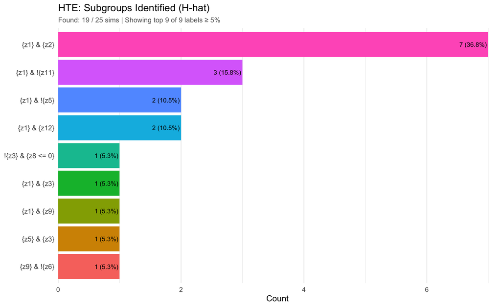

```r
print(plot_sgdist_alt)
```

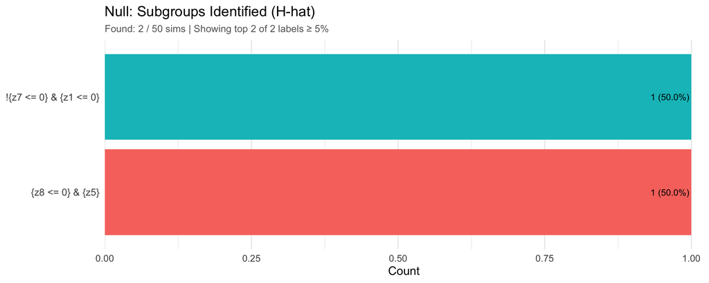

```r
print(plot_sgdist_null)
```

## 6.5 Distribution of MD Estimates

Three-panel violin of mean-difference (MD) estimates on the benefit scale across simulations: ITT, the identified $\hat H$, and its complement $\hat H^c$. Under H1 the dotted green line overlays the DGM-implied true MD$(Q)$ on the benefit scale. For additive measures, the “benefit scale” simply flips the sign of MD$(Q)$ under switched treatment roles.

**H1 MD-distribution violin (click to expand)**

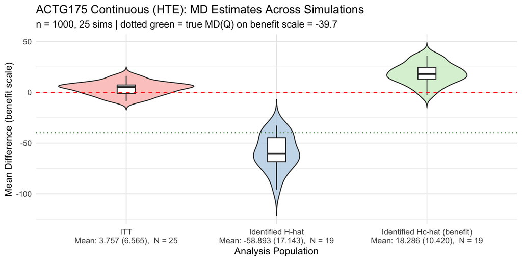

```r
md_Q_true <- -dgm_calibrated$hazard_ratios$harm_subgroup

plot_effect_distribution(
  results           = results_alt,
  analysis_method   = "FS",
  effect_measure    = "MD",
  subgroup_notation = sg_notation,
  reference_effect  = md_Q_true,
  title             = "ACTG175 Continuous (HTE): MD Estimates Across Simulations",
  subtitle          = sprintf(
    "n = %d, %d sims | dotted green = true MD(Q) on benefit scale = %.1f",
    sim_n_sample, nsims_alt, md_Q_true)
)
```

**H0 MD-distribution violin (click to expand)**

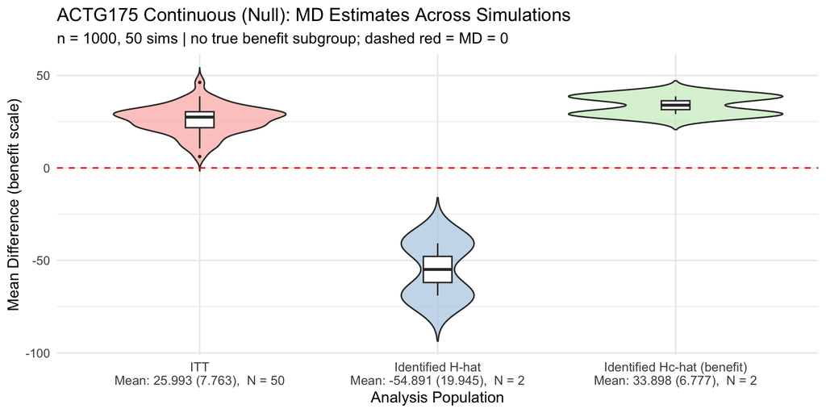

```r
plot_effect_distribution(
  results           = results_null,
  analysis_method   = "FS",
  effect_measure    = "MD",
  subgroup_notation = sg_notation,
  title             = "ACTG175 Continuous (Null): MD Estimates Across Simulations",
  subtitle          = sprintf(
    "n = %d, %d sims | no true benefit subgroup; dashed red = MD = 0",
    sim_n_sample, nsims_null)
)
```

# 7 Timing Summary

```r
timings$total <- Reduce(`+`, timings)

timing_df <- data.frame(
  Step = names(timings),
  Seconds = round(unlist(timings), 1),
  Minutes = round(unlist(timings) / 60, 2)
)

timing_df |>
  gt() |>
  gt::tab_header(title = "Computation Timing") |>
  gt::tab_style(
    style = gt::cell_text(weight = "bold"),
    locations = gt::cells_body(rows = Step == "total")
  )
```

Computation Timing

| Step | Seconds | Minutes |
| --- | --- | --- |
| data_prep | 0.0 | 0.00 |
| dgm_init | 0.0 | 0.00 |
| calibrate | 0.7 | 0.01 |
| dgm_null | 0.0 | 0.00 |
| single_trial | 0.0 | 0.00 |
| sims_alt | 12.4 | 0.21 |
| sims_null | 18.9 | 0.31 |
| report_alt | 0.1 | 0.00 |
| total | 32.1 | 0.53 |

# 8 Discussion

## 8.1 Key Design Decisions

1. **Positive k_inter, positive target**: Following the working binary simulation’s pattern, the DGM uses a positive `k_inter` to create a subgroup Q where ddI has an extreme positive effect (MD = +40). The population baseline effect is negative (ddI generally hurts), so there is a real Q vs Qc contrast that ForestSearch can detect.
2. **Identity-scale thresholds**: For continuous outcomes with `effect_measure = "MD"`, the screening and consistency thresholds are on the natural difference scale (e.g., MD >= 30 cells/$\mu$L). This differs from ratio-scale measures (HR, OR, IRR) where thresholds are multiplicative.
3. **Residual variance**: The DGM preserves the residual SD ($\sigma$) from the baseline Gaussian GLM fit, ensuring realistic noise levels in simulated data.
4. **Linear calibration**: For Gaussian GLM with identity link, `k_inter` maps linearly to MD(Q): $\text{MD}(Q) = \beta_T + k$ where $\beta_T$ is the fitted treatment coefficient. This makes calibration trivial compared to the non-linear binary (logistic) case.

## 8.2 Comparison with the Binary ACTG175 Simulation

- **No floor/ceiling effects**: continuous CD4 change has no natural bounds, so the DGM does not need the careful probability-clipping logic of the binary version.
- **Gaussian LASSO**: variable screening uses `glmnet` with `family = "gaussian"` instead of `"binomial"`.
- **Effect size interpretation**: MD = +40 cells/$\mu$L means ddI increases CD4 change by 40 more than combo for Q. On the original scale, this means combo provides 40 less CD4 benefit for Q.

# 10 References

- Hammer SM, et al. (1996). *NEJM*, 335, 1081–1090.
- León LF, et al. (2024). *Statistics in Medicine*, 43, 3921–3942.